# Week 8 - Homework

Aman Arora (amana4@illinois.edu)

## Exercise 1 (Writing Functions)

**(a)** Write a function named `diagnostics` that takes as input the arguments:

- `model`, an object of class `lm()`, that is a model fit via `lm()`
- `pcol`, for controlling point colors in plots, with a default value of `grey`
- `lcol`, for controlling line colors in plots, with a default value of `dodgerblue`
- `alpha`, the significance level of any test that will be performed inside the function, with a default value of `0.05`
- `plotit`, a logical value for controlling display of plots with default value `TRUE`
- `testit`, a logical value for controlling outputting the results of tests with default value `TRUE`

The function should output:

- A list with two elements when `testit` is `TRUE`:
  - `p_val`, the p-value for the Shapiro-Wilk test for assessing normality
  - `decision`, the decision made when performing the Shapiro-Wilk test using the `alpha` value input to the function. “Reject” if the null hypothesis is rejected, otherwise “Fail to Reject.”
- Two plots, side-by-side, when `plotit` is `TRUE`:
  - A fitted versus residuals plot that adds a horizontal line at $y = 0$, and labels the $x$-axis “Fitted” and the $y$-axis “Residuals.” The points and line should be colored according to the input arguments. Give the plot a title.
  - A Normal Q-Q plot of the residuals that adds the appropriate line using `qqline()`. The points and line should be colored according to the input arguments. Be sure the plot has a title.

Consider using this function to help with the remainder of the assignment as well.

```r
diagnostics <- function(model, pcol = "grey", lcol = "dodgerblue", alpha = 0.05, plotit = TRUE, testit = TRUE)
{
  result = list(p_val = 0, decision = "NA")
  if(plotit == TRUE)
  {
    par(mfrow = c(1,2))
    plot(fitted(model), resid(model), xlab = "Fitted", ylab = "Residuals", col = pcol )
    abline(h =0, col = lcol)

    qqnorm(resid(model),col = pcol )
    qqline(resid(model),col = lcol)

  }

  if(testit == TRUE)
  {
    stest = shapiro.test(resid(model))
    result[["p_val"]] =  stest$p.value
    result[["decision"]] = ifelse(stest$p.value >alpha,"Fail to Reject", "Reject")
    return (result)
  }

}
```

**(b)** Run the following code.

```r
set.seed(40)

data_1 = data.frame(x = runif(n = 30, min = 0, max = 10),
                    y = rep(x = 0, times = 30))
data_1$y = with(data_1, 2 + 1 * x + rexp(n = 30))
fit_1 = lm(y ~ x, data = data_1)

data_2 = data.frame(x = runif(n = 20, min = 0, max = 10),
                    y = rep(x = 0, times = 20))
data_2$y = with(data_2, 5 + 2 * x + rnorm(n = 20))
fit_2 = lm(y ~ x, data = data_2)

data_3 = data.frame(x = runif(n = 40, min = 0, max = 10),
                    y = rep(x = 0, times = 40))
data_3$y = with(data_3, 2 + 1 * x + rnorm(n = 40, sd = x))
fit_3 = lm(y ~ x, data = data_3)
```

```r
diagnostics(fit_1, plotit = FALSE)$p_val
```

```
## [1] 0.005613
```

```r
diagnostics(fit_2, plotit = FALSE)$decision
```

```
## [1] "Fail to Reject"
```

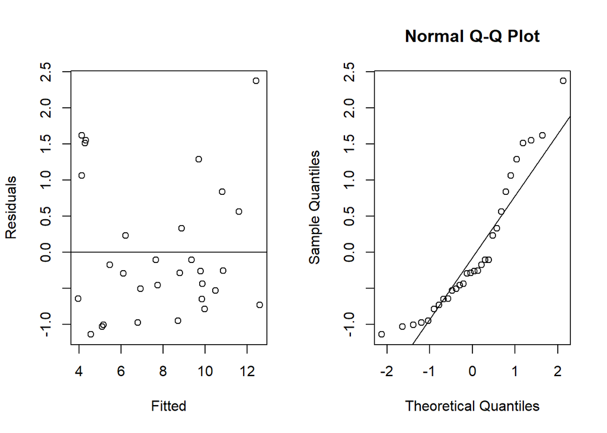

```r
diagnostics(fit_1, testit = FALSE, pcol = "black", lcol = "black")
```

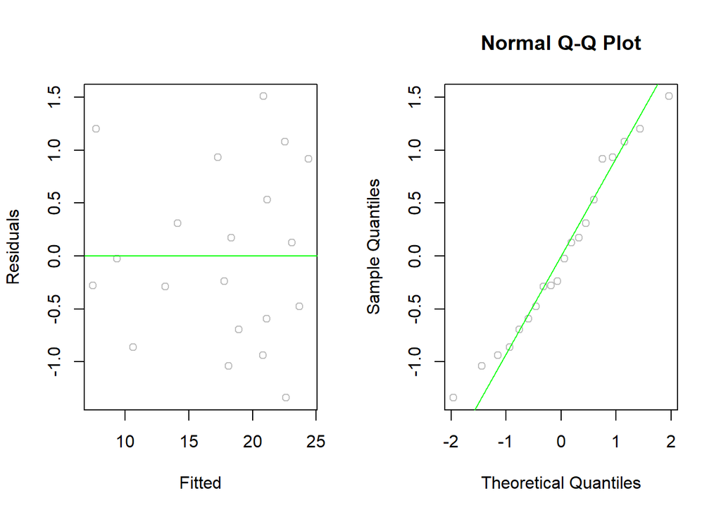

```r
diagnostics(fit_2, testit = FALSE, pcol = "grey", lcol = "green")
```

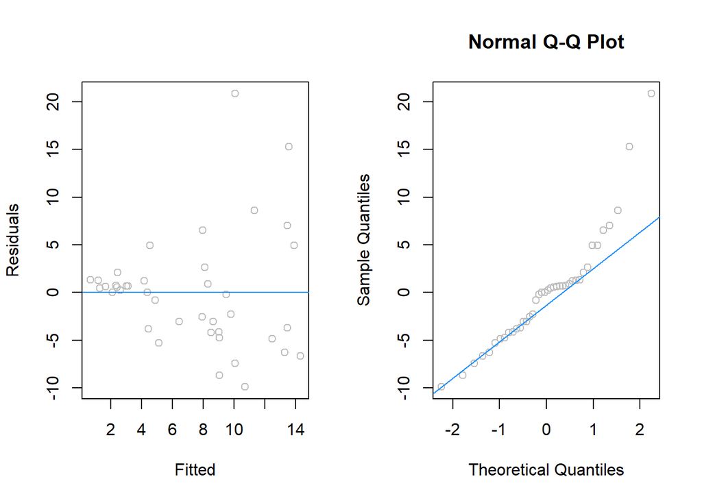

```
## $p_val
## [1] 0.001608
##
## $decision
## [1] "Reject"
```

```r
diagnostics(fit_3)
```

## Exercise 2 (Prostate Cancer Data)

For this exercise, we will use the `prostate` data, which can be found in the `faraway` package. After loading the `faraway` package, use `?prostate` to learn about this dataset.

```r
library(faraway)
```

**(a)** Fit an additive multiple regression model with `lpsa` as the response and the remaining variables in the `prostate` dataset as predictors. Report the $R^2$ value for this model.

```r
model_fit =  lm(lpsa~., data = prostate)
summary(model_fit)$r.squared
```

```
## [1] 0.6548
```

The $R^2$ value for this model is 0.6548

**(b)** Check the constant variance assumption for this model. Do you feel it has been violated? Justify your answer.

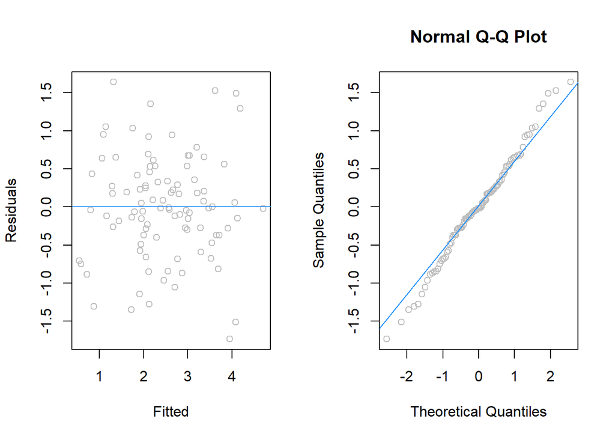

```
## $p_val
## [1] 0.7721
##
## $decision
## [1] "Fail to Reject"
```

```r
library(lmtest)
diagnostics(model_fit)
```

```r
bptest(model_fit)
```

```
##
##  studentized Breusch-Pagan test
##
## data:  model_fit
## BP = 10, df = 8, p-value = 0.3
```

- The constant variance assumption seems to holding based on visual inspection of the residual vs fitted graph and high p value of 0.3 from Breusch-Pagan test

**(c)** Check the normality assumption for this model. Do you feel it has been violated? Justify your answer.

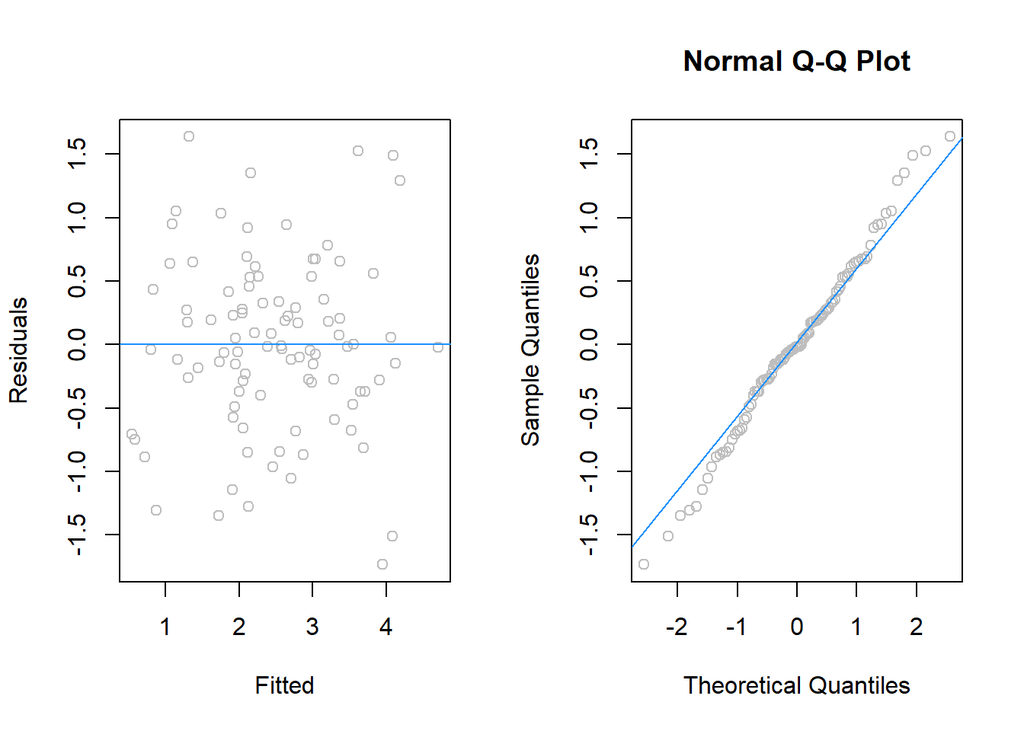

```
## $p_val
## [1] 0.7721
##
## $decision
## [1] "Fail to Reject"
```

```r
diagnostics(model_fit)
```

- The normal assumption seems to holding based on visual inspection of the QQ plot and supported by large p value from Shapiro-Wilk test.

**(d)** Check for any high leverage observations. Report any observations you determine to have high leverage.

```r
high_lev_idx = hatvalues(model_fit) > 2*mean(hatvalues(model_fit))

prostate [high_lev_idx,]
```

```
##    lcavol lweight age    lbph svi    lcp gleason pgg45  lpsa
## 32 0.1823   6.108  65  1.7047   0 -1.386       6     0 2.008
## 37 1.4231   3.657  73 -0.5798   0  1.658       8    15 2.158
## 41 0.6206   3.142  60 -1.3863   0 -1.386       9    80 2.298
## 74 1.8390   3.237  60  0.4383   1  1.179       9    90 3.075
## 92 2.5329   3.678  61  1.3481   1 -1.386       7    15 4.130
```

- There are 5 observations with high leverage as shown above

**(e)** Check for any influential observations. Report any observations you determine to be influential.

```r
influ_idx =  cooks.distance(model_fit) > 4/length(cooks.distance(model_fit))
prostate[influ_idx,]
```

```
##     lcavol lweight age    lbph svi    lcp gleason pgg45  lpsa
## 32  0.1823   6.108  65  1.7047   0 -1.386       6     0 2.008
## 39  2.6610   4.085  68  1.3737   1  1.833       7    35 2.214
## 47  2.7279   3.995  79  1.8795   1  2.657       9   100 2.569
## 69 -0.4463   4.409  69 -1.3863   0 -1.386       6     0 2.963
## 95  2.9074   3.396  52 -1.3863   1  2.464       7    10 5.143
## 96  2.8826   3.774  68  1.5581   1  1.558       7    80 5.478
## 97  3.4720   3.975  68  0.4383   1  2.904       7    20 5.583
```

- There are 7 influential observations as shown above

**(f)** Refit the additive multiple regression model without any points you identified as influential. Compare the coefficients of this fitted model to the previously fitted model.

```r
#Find indices of rows that do not have influential observations
retain_idx =  cooks.distance(model_fit) < 4/length(cooks.distance(model_fit))

#Fit a new model without influential observations
model_new = lm(lpsa ~ ., data = prostate[retain_idx,])

coef(model_fit)
```

```
## (Intercept)      lcavol     lweight         age        lbph         svi
##    0.669337    0.587022    0.454467   -0.019637    0.107054    0.766157
##         lcp     gleason       pgg45
##   -0.105474    0.045142    0.004525
```

```r
coef(model_new)
```

```
## (Intercept)      lcavol     lweight         age        lbph         svi
##    -0.24608     0.56499     0.54443    -0.01856     0.13328     0.74475
##         lcp     gleason       pgg45
##    -0.15542     0.11472     0.00665
```

The new coefficients after removing influential observations are significantly different than original coefficients.

**(g)** Create a data frame that stores the observations that were “removed” because they were influential. Use the two models you have fit to make predictions with these observations. Comment on the difference between these two sets of predictions.

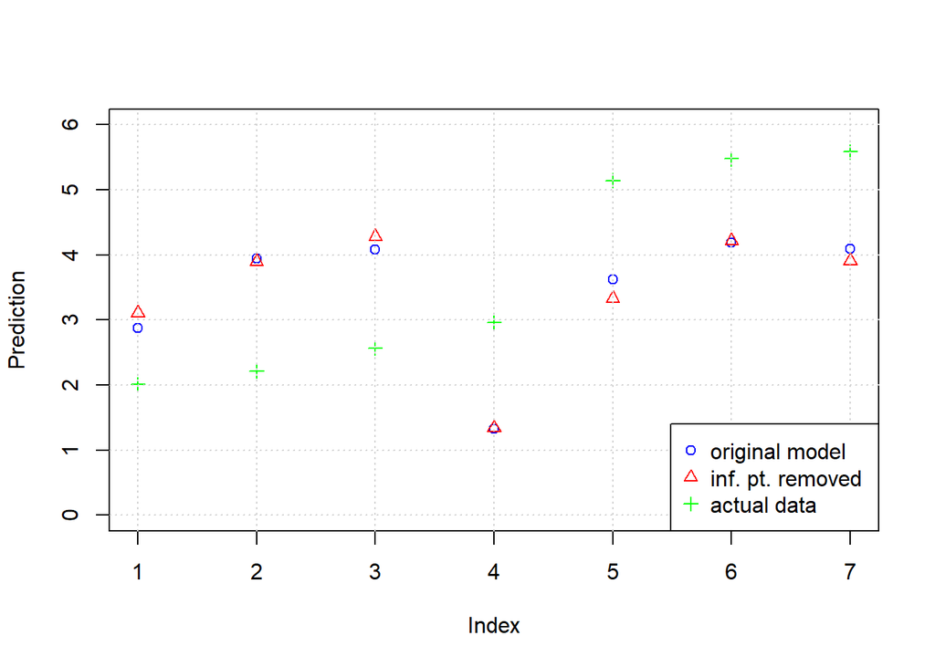

```r
#new data frame with influential observation
new_data1 = prostate[influ_idx,]

#predict with original model
result = predict(model_fit, newdata = new_data1)

#predict with model with influential observation removed
result_new = predict(model_new, newdata = new_data1)

#The actual response values
real = prostate[influ_idx, "lpsa"]

#Plot all the predictions and real data
plot(result, col = "blue", ylim = c(0,6), pch =1, ylab = "Prediction")

points(result_new,col = "red", pch =2)

points(real,col = "green", pch =3)
grid()

legend("bottomright", c("original model", "inf. pt. removed ","actual data"), col= c("blue","red","green"), pch = 1:3)
```

- We can see from the plot the prediction with original model are closer to actual value than the model which has the influential points removed.

## Exercise 3 (Why Bother?)

**Why** do we care about violations of assumptions? One key reason is that the distributions of the parameter estimators that we have used are all reliant on these assumptions. When the assumptions are violated, the distributional results are not correct, so our tests are garbage. **Garbage In, Garbage Out!**

Consider the following setup that we will use for the remainder of the exercise. We choose a sample size of 50.

```r
n = 50
set.seed(420)
x_1 = runif(n, 0, 5)
x_2 = runif(n, -2, 2)
```

Consider the model,

$$Y = 4 + 1 x_1 + 0 x_2 + \epsilon.$$

That is,

- $\beta_0$ = 4
- $\beta_1$ = 1
- $\beta_2$ = 0

We now simulate `y_1` in a manner that does **not** violate any assumptions, which we will verify. In this case $\epsilon \sim N(0, 1).$

```r
set.seed(83)
library(lmtest)
y_1 = 4 + 1 * x_1 + 0 * x_2 + rnorm(n = n, mean = 0, sd = 1)
fit_1 = lm(y_1 ~ x_1 + x_2)
bptest(fit_1)
```

```
##
##  studentized Breusch-Pagan test
##
## data:  fit_1
## BP = 4.4, df = 2, p-value = 0.1
```

Then, we simulate `y_2` in a manner that **does** violate assumptions, which we again verify. In this case $\epsilon \sim N(0, \sigma = |x_2|).$

```r
set.seed(83)
y_2 = 4 + 1 * x_1 + 0 * x_2 + rnorm(n = n, mean = 0, sd = abs(x_2))
fit_2 = lm(y_2 ~ x_1 + x_2)
bptest(fit_2)
```

```
##
##  studentized Breusch-Pagan test
##
## data:  fit_2
## BP = 4.9, df = 2, p-value = 0.08
```

**(a)** Use the following code after changing `birthday` to your birthday.

```r
num_sims = 2500
p_val_1 = rep(0, num_sims)
p_val_2 = rep(0, num_sims)
birthday = 19771212
set.seed(birthday)
```

Repeat the above process of generating `y_1` and `y_2` as defined above, and fit models with each as the response `2500` times. Each time, store the p-value for testing,

$$\beta_2 = 0,$$

using both models, in the appropriate variables defined above. (You do not need to use a data frame as we have in the past. Although, feel free to modify the code to instead use a data frame.)

```r
for(i in 1:num_sims)
{
  y_1 = 4 + 1 * x_1 + 0 * x_2 + rnorm(n = n, mean = 0, sd = 1)
  fit_1 = lm(y_1 ~ x_1 + x_2)
  p_val_1[i] =   bptest(fit_1)$p.value

  y_2 = 4 + 1 * x_1 + 0 * x_2 + rnorm(n = n, mean = 0, sd = abs(x_2))
  fit_2 = lm(y_2 ~ x_1 + x_2)
  p_val_2[i] =   bptest(fit_2)$p.value


}
```

**(b)** What proportion of the `p_val_1` values is less than 0.01? Less than 0.05? Less than 0.10? What proportion of the `p_val_2` values is less than 0.01? Less than 0.05? Less than 0.10? Arrange your results in a table. Briefly explain these results.

```r
library(knitr)

thresholds = c("< 0.01", "< 0.05", "< 0.1" )

p_val1_count  = c( mean(p_val_1 < .01), mean(p_val_1 < .05),mean(p_val_1 < .1)   )

p_val2_count  = c( mean(p_val_2 < .01),mean(p_val_2 < .05),mean(p_val_2 < .1)   )

result = data.frame("Thresholds" = thresholds, "Model 1 " =  p_val1_count, "Model 2 " =  p_val2_count )
```

Model Comparison

| Thresholds | Model.1. | Model.2. |
| --- | --- | --- |
| < 0.01 | 0.0072 | 0.0108 |
| < 0.05 | 0.0540 | 0.0732 |
| < 0.1 | 0.1108 | 0.1460 |

- We can see from the table above the with model 2, the no of p values is higher than thresholds is also greater i.e. there are more p values that indicate the presence of non constant variance vs model 1.
- We also see that the BP test does not always indicate the presence of non constant variance for model 2 (which we know has non constant variance) since the fraction of total values that are with in the threshold is always high i.e. BP test is not 100% accurate predictor of non constant variance.
- Conversely we also see that the BP test flags constant variance data (model 1) as non constant for fraction of the runs. Again reinforcing the conclusion that its not a fully accurate method to test for non constant variance.

## Exercise 4 (Corrosion Data)

For this exercise, we will use the `corrosion` data, which can be found in the `faraway` package. After loading the `faraway` package, use `?corrosion` to learn about this dataset.

```r
library(faraway)
```

**(a)** Fit a simple linear regression with `loss` as the response and `Fe` as the predictor. Plot a scatterplot and add the fitted line. Check the assumptions of this model.

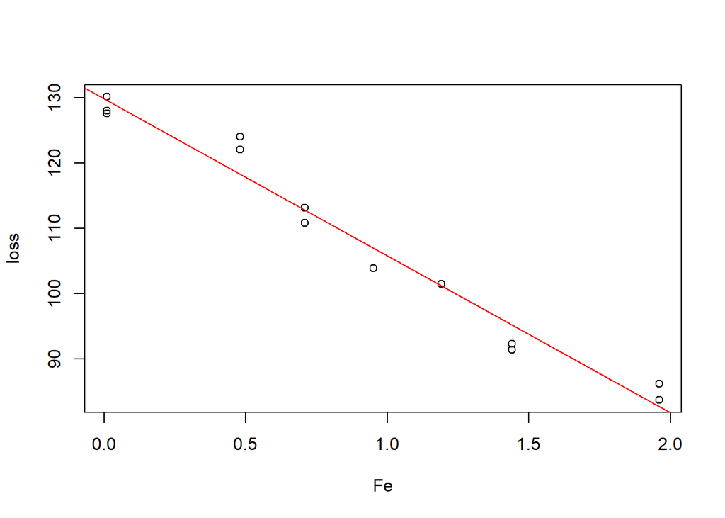

```r
fitted_model = lm(loss~Fe, data = corrosion )

plot(loss~Fe, data = corrosion)
abline(fitted_model, col = "red")
```

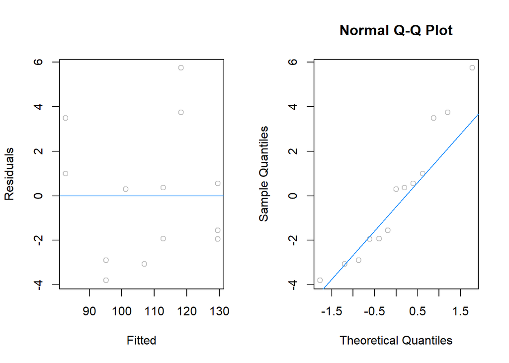

```
## $p_val
## [1] 0.3733
##
## $decision
## [1] "Fail to Reject"
```

```r
#Evaluate the assumptions
diagnostics(fitted_model)
```

```r
bptest(fitted_model)
```

```
##
##  studentized Breusch-Pagan test
##
## data:  fitted_model
## BP = 0.025, df = 1, p-value = 0.9
```

- The assumption of constant variance seems to hold from fitted vs residual plot and high p value from Breusch-Pagan test
- The assumption of normal residuals seems to hold from Q-Q plot and high p value from Shapiro-Wilks test

**(b)** Fit higher order polynomial models of degree 2, 3, and 4. For each, plot a fitted versus residuals plot and comment on the constant variance assumption. Based on those plots, which of these three models do you think are acceptable? Use a statistical test(s) to compare the models you just chose. Based on the test, which is preferred? Check the normality assumption of this model. Identify any influential observations of this model.

```r
library(knitr )
model2 = lm(loss~ Fe + I(Fe^2), data = corrosion )
model3 = lm(loss~ Fe + I(Fe^2) + I(Fe^3), data = corrosion )
model4 = lm(loss~ Fe + I(Fe^2)+ I(Fe^3)+ I(Fe^4), data = corrosion )

name_model = c("2nd degree", "3rd degree", "4th Degree" )
p_val  = c(diagnostics(model2)$p_val, diagnostics(model3)$p_val, diagnostics(model4)$p_val)
```

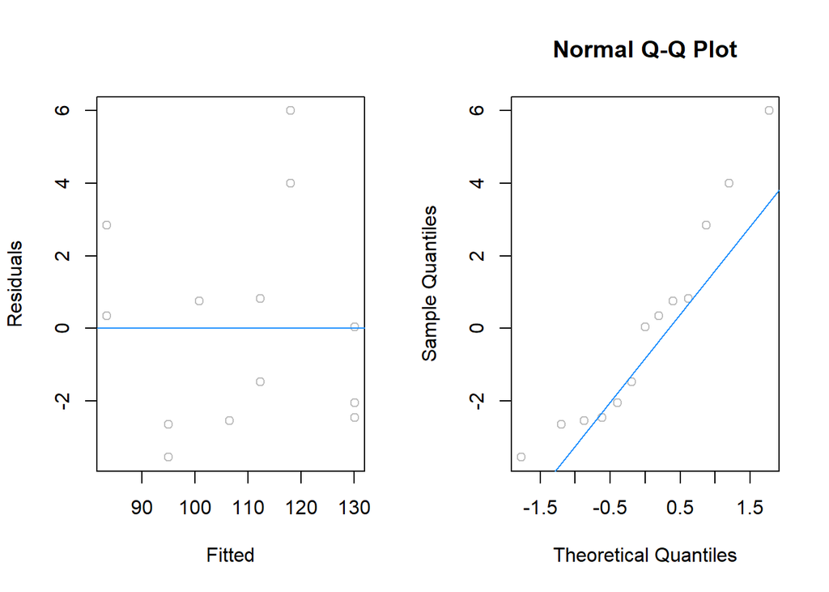

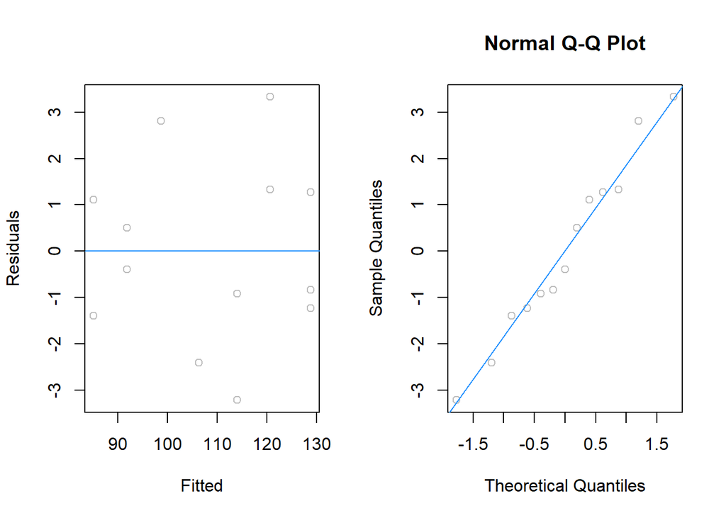

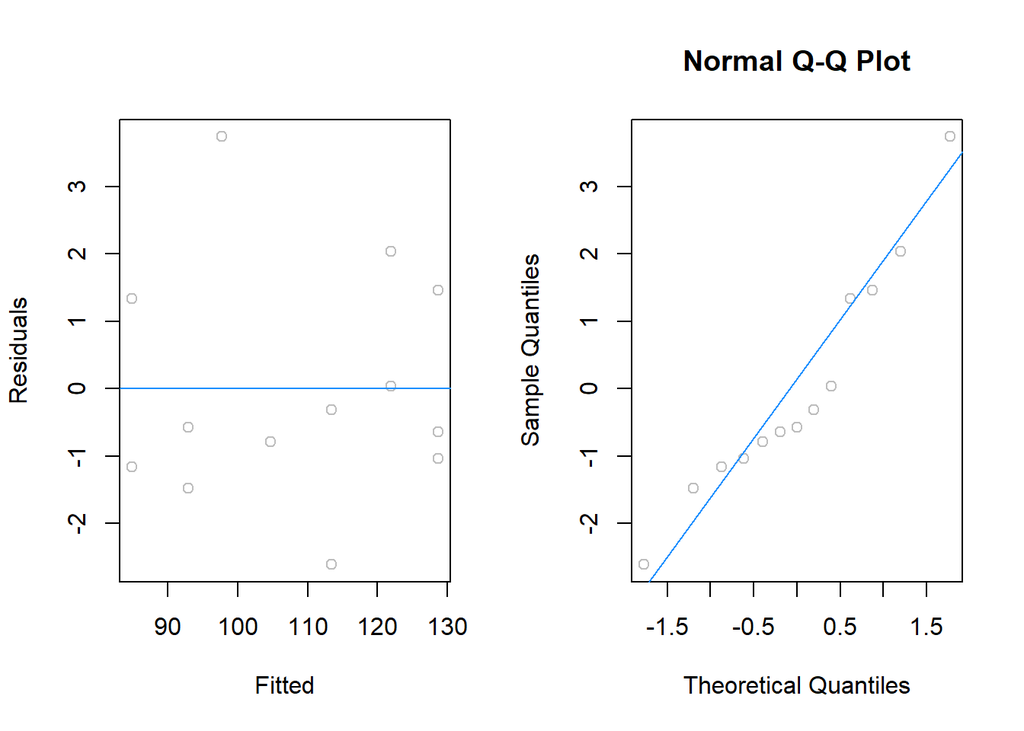

```r
result = data.frame("Model Type" = name_model, "Shaprio(p value) " =  p_val )
```

Model Comparison

| Model.Type | Shaprio.p.value.. |
| --- | --- |
| 2nd degree | 0.2565 |
| 3rd degree | 0.9085 |
| 4th Degree | 0.4022 |

- Based on the plots above the model with order 3 seems be most appropriate with constant variance and normal residuals.

```r
#Check for significance of 3rd order term
anova(model2,model3)
```

```
## Analysis of Variance Table
##
## Model 1: loss ~ Fe + I(Fe^2)
## Model 2: loss ~ Fe + I(Fe^2) + I(Fe^3)
##   Res.Df   RSS Df Sum of Sq  F Pr(>F)
## 1     10 100.1
## 2      9  45.1  1        55 11  0.009 **
## ---
## Signif. codes:  0 '***' 0.001 '**' 0.01 '*' 0.05 '.' 0.1 ' ' 1
```

```r
#Check for significance of 4th order term
anova(model3,model4)
```

```
## Analysis of Variance Table
##
## Model 1: loss ~ Fe + I(Fe^2) + I(Fe^3)
## Model 2: loss ~ Fe + I(Fe^2) + I(Fe^3) + I(Fe^4)
##   Res.Df  RSS Df Sum of Sq   F Pr(>F)
## 1      9 45.1
## 2      8 35.0  1      10.1 2.3   0.17
```

- Based on the ANOVA tests the 3rd order term seems to be significant while 4th order term is not. We thus prefer the model with degree of 3.

```r
bptest(model3)
```

```
##
##  studentized Breusch-Pagan test
##
## data:  model3
## BP = 4.8, df = 3, p-value = 0.2
```

```r
inf_idx =  cooks.distance(model3) >  4/length(cooks.distance(model3))
corrosion[inf_idx,]
```

```
## [1] Fe   loss
## <0 rows> (or 0-length row.names)
```

- No influential observations were found in the data for the model with degree 3.

## Exercise 5 (Diamonds)

The data set `diamonds` from the `ggplot2` package contains prices and characteristics of 54,000 diamonds. For this exercise, use `price` as the response variable $y$, and `carat` as the predictor $x$. Use `?diamonds` to learn more.

```r
library(ggplot2)
```

**(a)** Fit a linear model with `price` as the response variable $y$, and `carat` as the predictor $x$. Return the summary information of this model.

```r
model1 = lm(price ~ carat, data = diamonds )
summary(model1)
```

```
##
## Call:
## lm(formula = price ~ carat, data = diamonds)
##
## Residuals:
##    Min     1Q Median     3Q    Max
## -18585   -805    -19    537  12732
##
## Coefficients:
##             Estimate Std. Error t value Pr(>|t|)
## (Intercept)  -2256.4       13.1    -173   <2e-16 ***
## carat         7756.4       14.1     551   <2e-16 ***
## ---
## Signif. codes:  0 '***' 0.001 '**' 0.01 '*' 0.05 '.' 0.1 ' ' 1
##
## Residual standard error: 1550 on 53938 degrees of freedom
## Multiple R-squared:  0.849,  Adjusted R-squared:  0.849
## F-statistic: 3.04e+05 on 1 and 53938 DF,  p-value: <2e-16
```

**(b)** Plot a scatterplot of price versus carat and add the line for the fitted model in part **(a)**. Using a fitted versus residuals plot and/or a Q-Q plot, comment on the diagnostics.

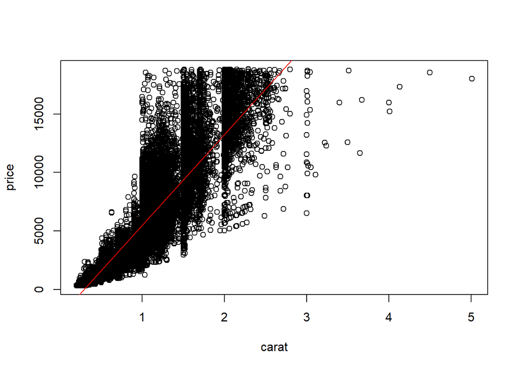

```r
plot(price ~ carat, data = diamonds)
abline(model1, col = "red")
```

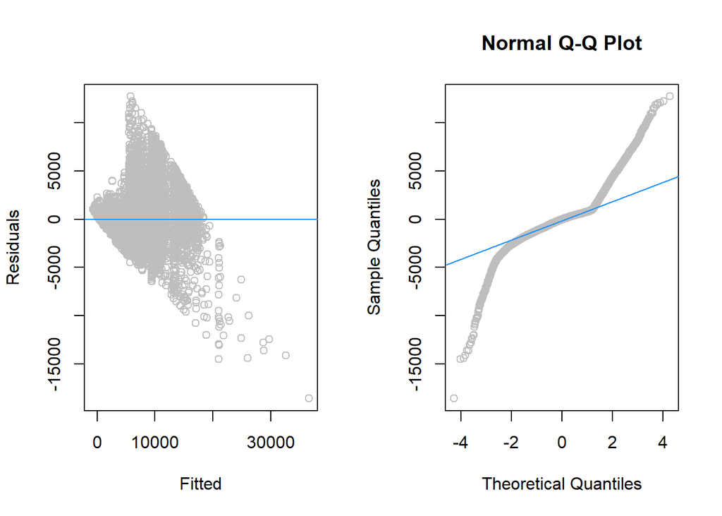

```r
diagnostics(model1, testit = FALSE)
```

- From Residuals vs fitted plot we see constant variance assumption is not appropriate for this model and data.
- From Q-Q plot we see constant normality assumption does not look valid.

**(c)** Seeing as the price stretches over several orders of magnitude, it seems reasonable to try a log transformation of the response. Fit a model with a logged response, plot a scatterplot of log-price versus carat and add the line for the fitted model, then use a fitted versus residuals plot and/or a Q-Q plot to comment on the diagnostics of the model.

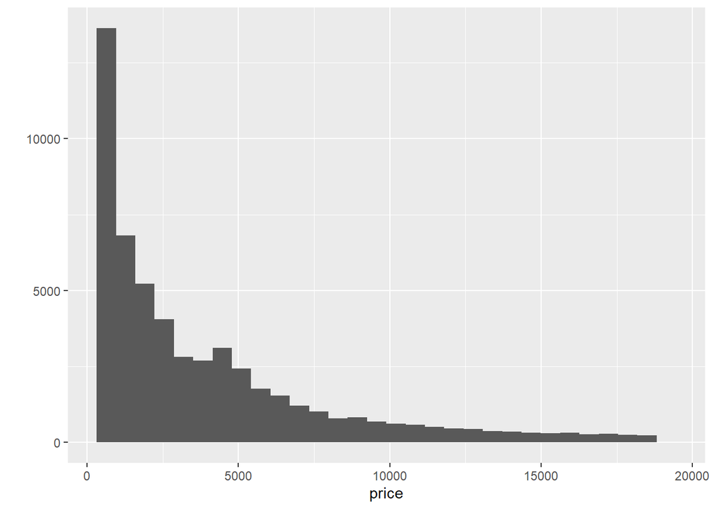

```r
qplot(price, data = diamonds, bins = 30)
```

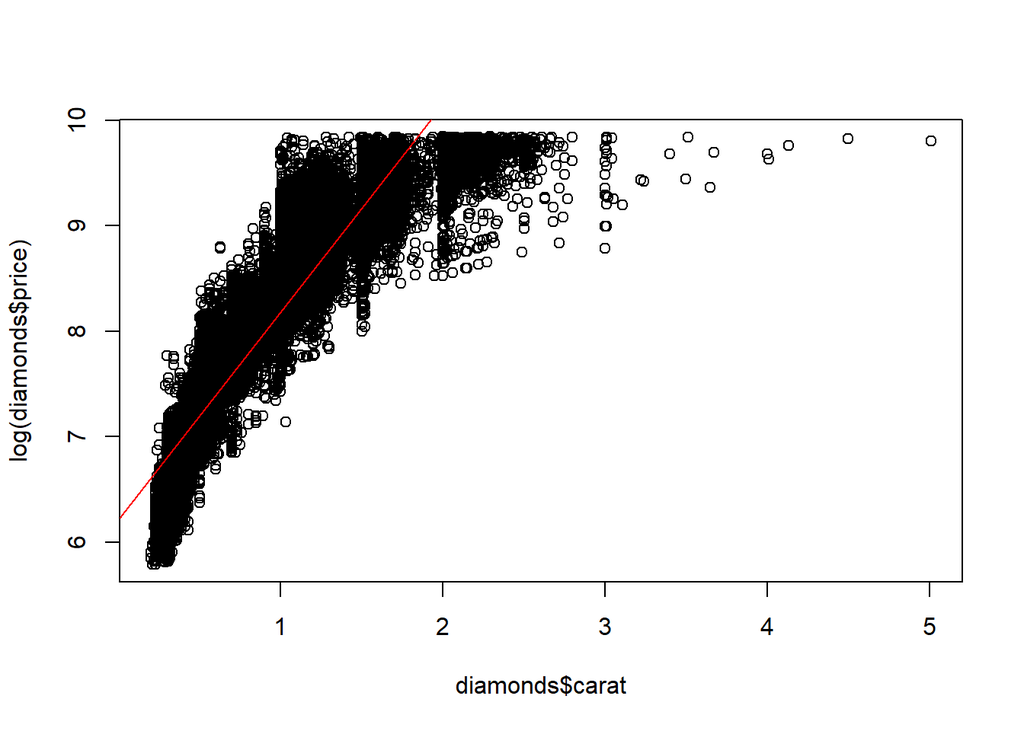

```r
model2 = lm(log(price) ~ carat, data = diamonds)

plot(diamonds$carat, log(diamonds$price))
abline(model2, col = "red")
```

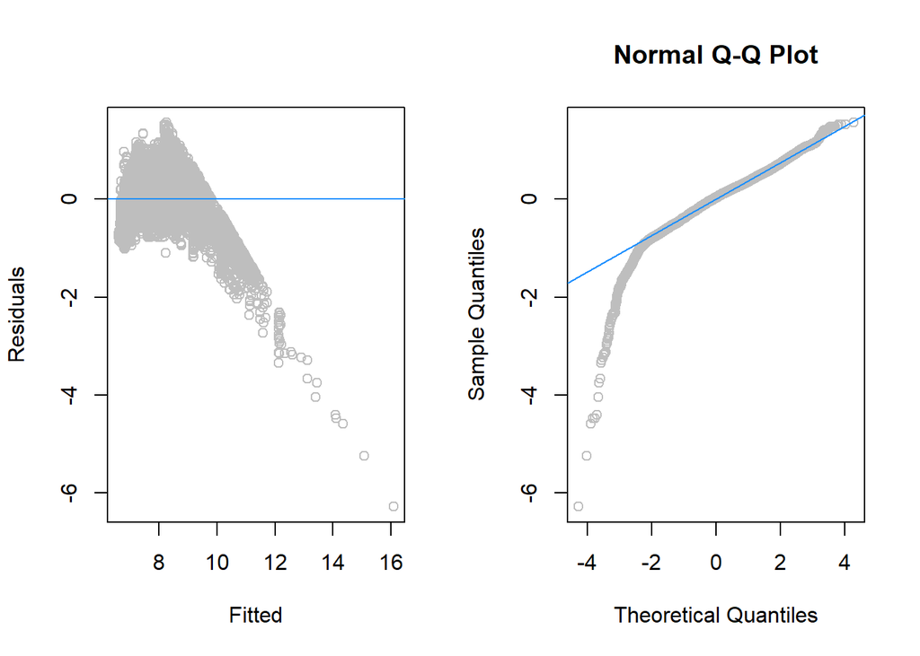

```r
diagnostics(model2, testit = FALSE)
```

- From Residuals vs fitted plot we do not see constant variance assumption is appropriate for this model and data.
- From Q-Q plot we see constant normality assumption does not look valid.

**(d)** Try adding log transformation of the predictor. Fit a model with a logged response and logged predictor, plot a scatterplot of log-price versus log-carat and add the line for the fitted model, then use a fitted versus residuals plot and/or a Q-Q plot to comment on the diagnostics of the model.

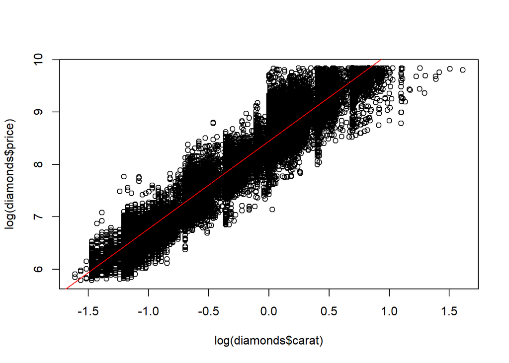

```r
model3 = lm(log(price) ~ log(carat), data = diamonds)

plot(log(diamonds$carat), log(diamonds$price))
abline(model3, col = "red")
```

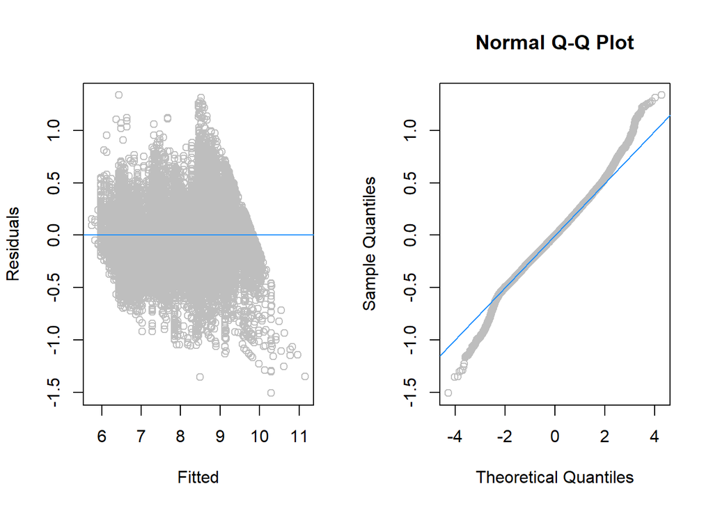

```r
diagnostics(model3, testit = FALSE)
```

- From Residuals vs fitted plot we do see constant variance assumption seems appropriate for this model and data vs previous models although not prefect.
- From Q-Q plot we see constant normality assumption does look valid vs previous models although not perfect.

**(e)** Use the model from part **(d)** to predict the price (in dollars) of a 3-carat diamond. Construct a 99% prediction interval for the price (in dollars).

```r
newdata1 = data.frame(carat = 3)
result = predict(model3, newdata = newdata1, interval = "prediction", level = 0.99)
result_dollars = exp(result)
```

99% prediction interval of price for a 3-carat diamond is (14959, 57894)